# LuthraSauravPS1

Saurav Luthra

2025-01-23

# SAURAV LUTHRA, MTH643 PROBLEM SET 1

## Overview.

In each of the three following questions, different stochastic processes **(W, V, U)** are simulated. Each stochastic process is the cumulative sum of a series of random underlying variables **(X, Y, Z)**. Each simulation path has 200 time steps over which its value evolves. 10,000 simulations were run for each process to get a large sample size. These simulation were then used to estimate the probability of these outcomes:  
I. The ending value of the process (200<sup>th</sup> time step) is ≥ 10.

2. The maximum value over the entire process path is ≥ 10.

Using binomial/normal probability distributions, the theoretical probabilities of these outcomes was also found.

## QUESTION 1.

#### **Stochastic Process W**

Simulating the following process,

$$W_k = X_1 + ... + X_k$$
$$X_k = \begin{cases} +1, & \text{p = 0.50 }
\\-1, & \text{p = 0.50 } \\\end{cases}$$

**By simulation the probabilities were:**

**The theoretical probability is:**

P (W<sub>200</sub> ≥ 10) = 0.2623112

which is very similar to the result that was obtained by simulation.

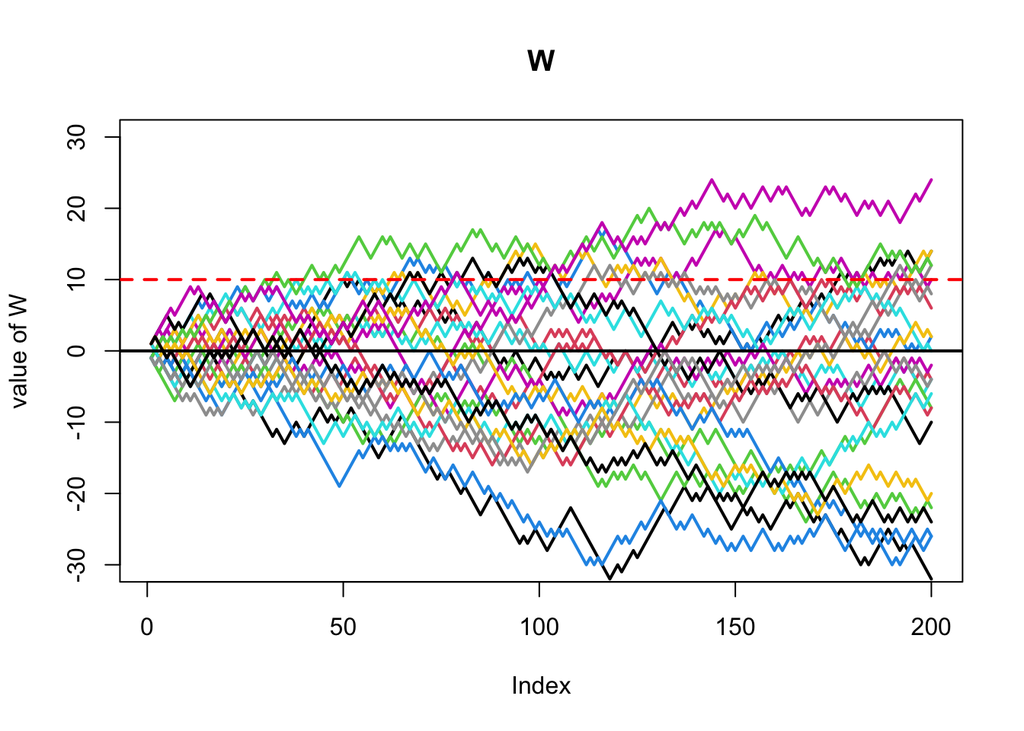

```r
# ==============================================================================
# SETUP

# simulation parameters
simulations <- 10000
numsteps    <- 200

# array of random Bernoulli (-1 or 1) variable arrays
Xarrs   <- list()
# array of W-paths (arrays) using cumsum()
Warrs   <- list()
# array of all final ending simulation values (W200)
W200Arr <- list()
# array of max values of each simulation
WmaxArr <- list()

# ==============================================================================
# SIMULATION

# generate simulation results and record ending and max values for W
for (i in 1:simulations) {
  Xarrs[[i]] <- 2 * rbinom(numsteps, 1, 0.5) - 1
  Warrs[[i]] <- cumsum(Xarrs[[i]])
  W200Arr[[i]] <- Warrs[[i]][numsteps]
  WmaxArr[[i]] <- max(Warrs[[i]])
}

# ==============================================================================
# OUTPUT SIMULATION RESULTS

# Plot 25 example simulation paths
plot(Warrs[[1]], type = "l", col = 1, lwd = 2, xlab = "Index", ylab = "value of W", main = "W", ylim = c(-30, 30))
for (i in 2:25) {
  lines(Warrs[[i]], col = i, lwd = 2)
}
abline(h = 0, col = "black", lty = 1, lwd = 2)
abline(h = 10, col = "red", lty = 2, lwd = 2)
```

```r
# output number of W200 values that are >= 10
W200count <- sum(W200Arr >= 10)
cat("\nW200 Count/Simulations = ", W200count, "/", simulations)
```

```
##
## W200 Count/Simulations =  2638 / 10000
```

```r
cat("\nP[W200 >= 10]          = ", (W200count/simulations))
```

```
##
## P[W200 >= 10]          =  0.2638
```

```r
# output the number of Wmax values that are >= 10
Wmaxcount <- sum(WmaxArr >= 10)
cat("\n\nWmax Count/Simulations = ", Wmaxcount, "/", simulations)
```

```
##
##
## Wmax Count/Simulations =  4817 / 10000
```

```r
cat("\nP[Wmax >= 10]          = ", (Wmaxcount/simulations))
```

```
##
## P[Wmax >= 10]          =  0.4817
```

```r
# ==============================================================================
# THORETICAL VALUES

# for W200 to be >= 10, we need at least 10 more up-moves than down-moves
# we need to count the probability that: up-moves - down-moves >= 10
# in the case of 200 steps, we need the probability of getting >=105 up-moves (meaning <=95 down-moves)

probability <- pbinom(104, 200, 0.5, lower.tail = FALSE)
cat("\n\nTheoretical Probability of W200 >= 10: ", probability)
```

```
##
##
## Theoretical Probability of W200 >= 10:  0.2623112
```

## QUESTION 2.

#### **Stochastic Process V**

Simulate the following stochastic process,

$$V_k = Y_1 + ... + Y_k$$
$$Y_k = \begin{cases} +1, & \text{p = 0.55 }
\\-1, & \text{p = 0.45 } \\\end{cases}$$

**By simulation the probabilities were:**

**The theoretical probability is:**

P (V<sub>200</sub> ≥ 10) = 0.78305

which is very similar to the result that was obtained by simulation.

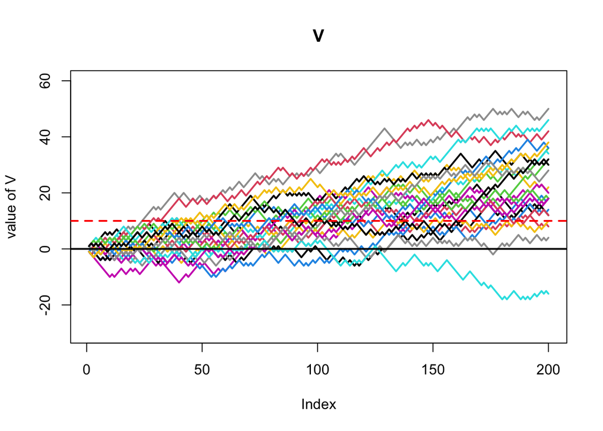

```r
# ==============================================================================
# SETUP

# simulation parameters
simulations <- 10000
numsteps    <- 200

# array of random Bernoulli (-1 or 1) variable arrays
Yarrs   <- list()
# array of V-paths (arrays) using cumsum()
Varrs   <- list()
# array of all final ending simulation values (V200)
V200Arr <- list()
# array of max values of each simulation
VmaxArr <- list()

# ==============================================================================
# SIMULATION

# Generate simulation results and find ending and max values for V
for (i in 1:simulations) {
  Yarrs[[i]] <- 2 * rbinom(numsteps, 1, 0.55) - 1
  Varrs[[i]] <- cumsum(Yarrs[[i]])
  V200Arr[[i]] <- Varrs[[i]][numsteps]
  VmaxArr[[i]] <- max(Varrs[[i]])
}

# ==============================================================================
# OUTPUT SIMULATION RESULTS

# Plot 25 example simulation paths
plot(Varrs[[1]], type = "l", col = 1, lwd = 2, xlab = "Index", ylab = "value of V", main = "V", ylim = c(-30, 60))
for (i in 2:25) {
  lines(Varrs[[i]], col = i, lwd = 2)
}
abline(h = 0, col = "black", lty = 1, lwd = 2)
abline(h = 10, col = "red", lty = 2, lwd = 2)
```

```r
# output number of V200 values that are >= 10
V200count <- sum(V200Arr >= 10)
cat("\nV200 Count/Simulations = ", V200count, "/", simulations)
```

```
##
## V200 Count/Simulations =  7746 / 10000
```

```r
cat("\nP[V200 >= 10]          = ", (V200count/simulations))
```

```
##
## P[V200 >= 10]          =  0.7746
```

```r
# output the number of Vmax values that are >= 10
Vmaxcount <- sum(VmaxArr >= 10)
cat("\n\nVmax Count/Simulations = ", Vmaxcount, "/", simulations)
```

```
##
##
## Vmax Count/Simulations =  8844 / 10000
```

```r
cat("\nP[Vmax >= 10]          = ", (Vmaxcount/simulations))
```

```
##
## P[Vmax >= 10]          =  0.8844
```

```r
# ==============================================================================
# THORETICAL VALUES

# for V200 to be >= 10, the we need at least 10 more up-moves than down-moves
# we need to count the probability that: up-moves - down-moves >= 10
# in the case of 200 steps, we need the probability of getting >=105 up-moves (meaning <=95 down-moves)

probability <- pbinom(104, 200, 0.55, lower.tail = FALSE)
cat("\n\nTheoretical Probability of V200 >= 10: ", probability)
```

```
##
##
## Theoretical Probability of V200 >= 10:  0.78305
```

## QUESTION 3.

#### **Stochastic Process U**

Simulate the following process,

$$U_k = Z_1 + ... + Z_k$$
$$Z_k \sim N(0,1)$$

Being the sum of 200 standard normal random variables, U<sub>200</sub> is a normal random variable with mean 0 and variance 200.
$$U_{200} = \sum_{k=1}^{200}Z_k \sim
N(0,200)$$

**By simulation the probabilities were:**

**The theoretical probability is:**

P (U<sub>200</sub> ≥ 10) = 0.2397501

which is very similar to the result that was obtained by simulation.

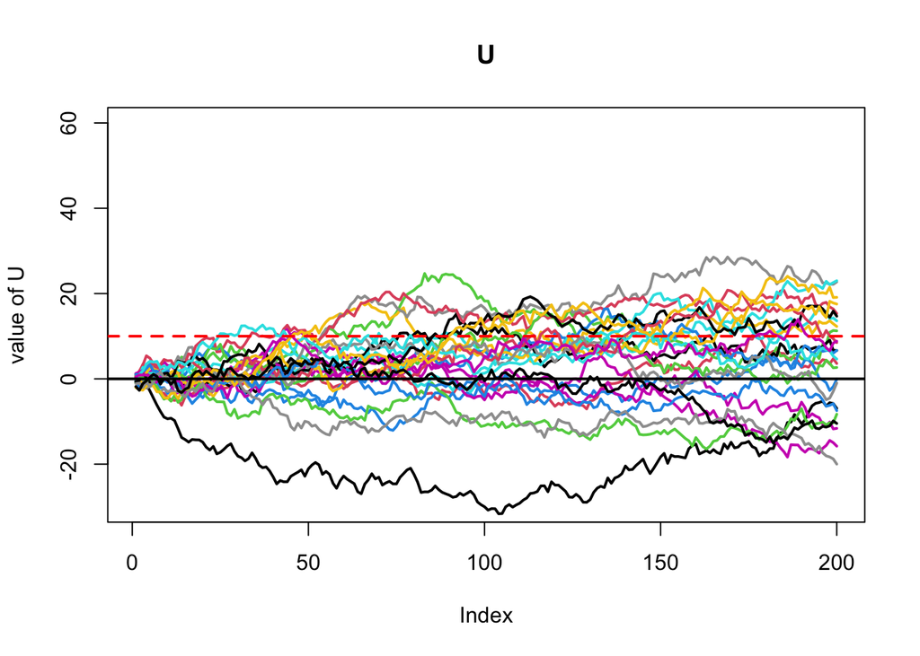

```r
# ==============================================================================
# SETUP

# simulation parameters
simulations <- 10000
numsteps    <- 200

# array of random std-normal variable arrays
Zarrs   <- list()
# array of U-paths (arrays) using cumsum()
Uarrs   <- list()
# array of all final ending simulation values (U200)
U200Arr <- list()
# array of max values of each simulation
UmaxArr <- list()

# ==============================================================================
# SIMULATION

# Generate simulation results and find ending and max values for U
for (i in 1:simulations) {
  Zarrs[[i]]   <- rnorm(numsteps)
  Uarrs[[i]]   <- cumsum(Zarrs[[i]])
  U200Arr[[i]] <- Uarrs[[i]][numsteps]
  UmaxArr[[i]] <- max(Uarrs[[i]])
}

# ==============================================================================
# OUTPUT SIMULATION RESULTS

# Plot 25 example simulation paths
plot(Uarrs[[1]], type = "l", col = 1, lwd = 2, xlab = "Index", ylab = "value of U", main = "U", ylim = c(-30, 60))
for (i in 2:25) {
  lines(Uarrs[[i]], col = i, lwd = 2)
}
abline(h = 0, col = "black", lty = 1, lwd = 2)
abline(h = 10, col = "red", lty = 2, lwd = 2)
```

```r
# output number of U200 values that are >= 10
U200count <- sum(U200Arr >= 10)
cat("\nU200 Count/Simulations = ", U200count, "/", simulations)
```

```
##
## U200 Count/Simulations =  2323 / 10000
```

```r
cat("\nP[U200 >= 10]          = ", (U200count/simulations))
```

```
##
## P[U200 >= 10]          =  0.2323
```

```r
# output the number of Umax values that are >= 10
Umaxcount <- sum(UmaxArr >= 10)
cat("\n\nUmax Count/Simulations = ", Umaxcount, "/", simulations)
```

```
##
##
## Umax Count/Simulations =  4528 / 10000
```

```r
cat("\nP[Umax >= 10]          = ", (Umaxcount/simulations))
```

```
##
## P[Umax >= 10]          =  0.4528
```

```r
# ==============================================================================
# THORETICAL VALUES

# since U200 = Z1 + Z2 + ... + Z200, we can express U200 as the sum of 200 independent standard-normal random variables.
# Thus, U200 itself is a normal random variable
# mu = 0
# var(U200) = 200 x 1 = 200

probability <- pnorm(10, mean=0, sd=sqrt(200), lower.tail = FALSE)
cat("\n\nTheoretical Probability of U200 >= 10: ", probability)
```

```
##
##
## Theoretical Probability of U200 >= 10:  0.2397501
```